# Homework-06: Correlation And Regression Homework

## 31.a) Calculate a regression line that best describes the relationship between year of painting and the portion size. What is the trend? How rapidly has portion size changed in paintings?

```r
year.size.art<-read.csv("http://whitlockschluter.zoology.ubc.ca/wp-content/data/chapter17/chap17q31LastSupperPortionSize.csv")
year.size.lm<-lm(portionSize ~ year, data=year.size.art)
year.size.lm
```

```
##
## Call:
## lm(formula = portionSize ~ year, data = year.size.art)
##
## Coefficients:
## (Intercept)         year
##   -1.168842     0.003329
```

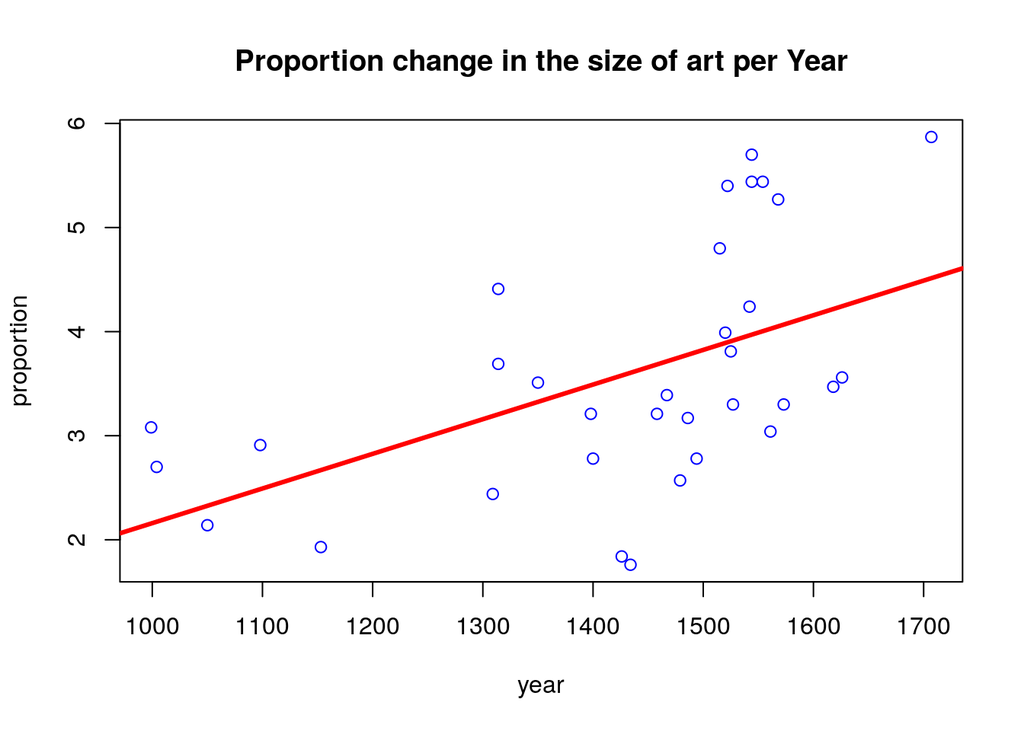

```r
yrsize.slope<-year.size.lm$coefficients
intercept<-as.numeric(yrsize.slope[1])
rate.of.delta<-as.numeric(yrsize.slope[2])
plot(y=year.size.art$portionSize, x=year.size.art$year, main="Proportion change in the size of art per Year", xlab="year", ylab="proportion", col="blue")
abline(intercept,rate.of.delta, col=2,lwd=3)
```

## 31.b) What is the most-plausible range of values for the slope of this relationship? Calculate a 95% confidence interval.

```r
slope.conf.int<-confint(year.size.lm,level=0.95)
slope.conf.int
```

```
##                    2.5 %      97.5 %
## (Intercept) -4.014924002 1.677239200
## year         0.001349556 0.005308266
```

```r
paste("The 95% confidence interval for the slope of this relationship is from", round(slope.conf.int[2,1],digits=5),"to", round(slope.conf.int[2,2],digits=5))
```

```
## [1] "The 95% confidence interval for the slope of this relationship is from 0.00135 to 0.00531"
```

## 31.c) Test for a change in relative portion size painted in these works of art with the year in which they were painted.12

```r
incremental.delta.per.yr<-c()
incremental.delta.per.yr[1]<-0
incremental.delta.per.yr[2:33]<-(year.size.art$portionSize[2:33]/year.size.art$portionSize[1:32])/(year.size.art$year[2:33]-year.size.art$year[1:32])
incremental.delta.per.yr
```

```
##  [1]  0.0000000000  0.1753246753  0.0172302738  0.0283294393  0.0058705613
##  [6]           Inf  0.0221088435 -0.0169550413  0.0147817278  0.4330218069
## [11]  0.0182003651 -0.1052114061  0.0352692479  0.1096214511 -0.0616306954
## [16]  0.0267509728 -0.5772727273 -0.2094488189  0.0483025746 -0.0419287212
## [21]  0.1607142857  0.0212157810 -0.0737327189 -0.1000000000           Inf
## [26]  0.0313725490  0.0904605263  0.0233670034  0.1282420749  0.0203564988
## [31] -0.0005934846  0.0032452566 -0.1306818182
```

```r
#year.size.art.delta<-cbind(year.size.art,incremental.delta.per.yr)
anova(year.size.lm)
```

```
## Analysis of Variance Table
##
## Response: portionSize
##           Df Sum Sq Mean Sq F value   Pr(>F)
## year       1 11.782 11.7819  11.765 0.001727 **
## Residuals 31 31.043  1.0014
## ---
## Signif. codes:  0 '***' 0.001 '**' 0.01 '*' 0.05 '.' 0.1 ' ' 1
```

> 31.c) Answer: Performing an f-test test on change in the relative proportion size of paintings per year produced a p-value well below the standard alpha level. This suggests that the null hypothesis that the relative change in proportion size per year is equal to zero, should be rejected in favor of consideration of the alternative hypothesis.

## 31.d) Draw a residual plot of these data and examine it carefully. Can you see any cause for concern about using a linear regression? Suggest an approach that could be tried to address the problem.

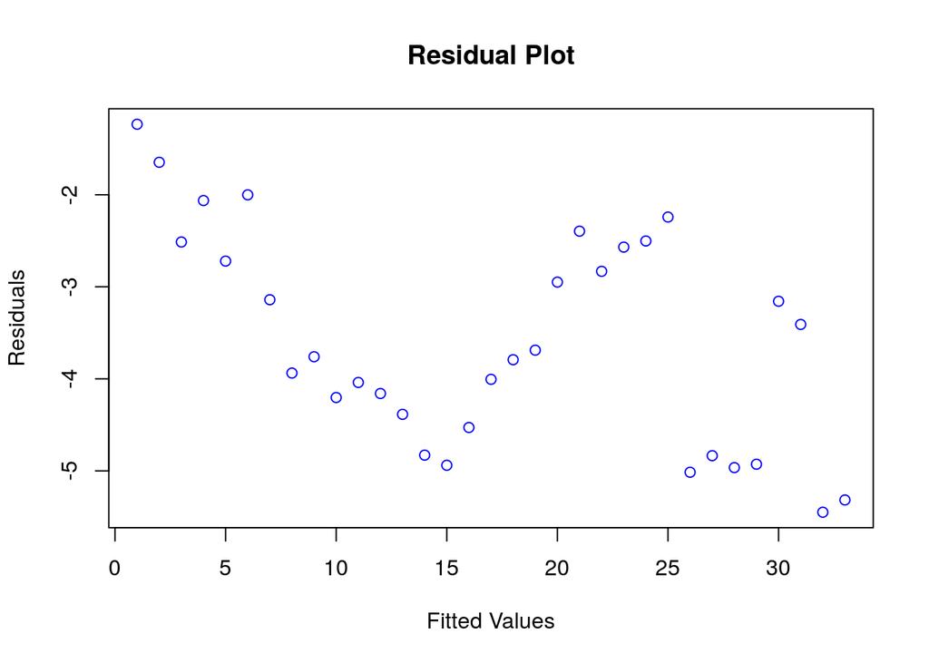

```r
library(modelr)
year.size.art %>%
  add_residuals(year.size.lm) -> year.size.art

plot(year.size.art$resid - fitted(year.size.lm), ylab="Residuals",xlab="Fitted Values", main="Residual Plot", col="blue")
```

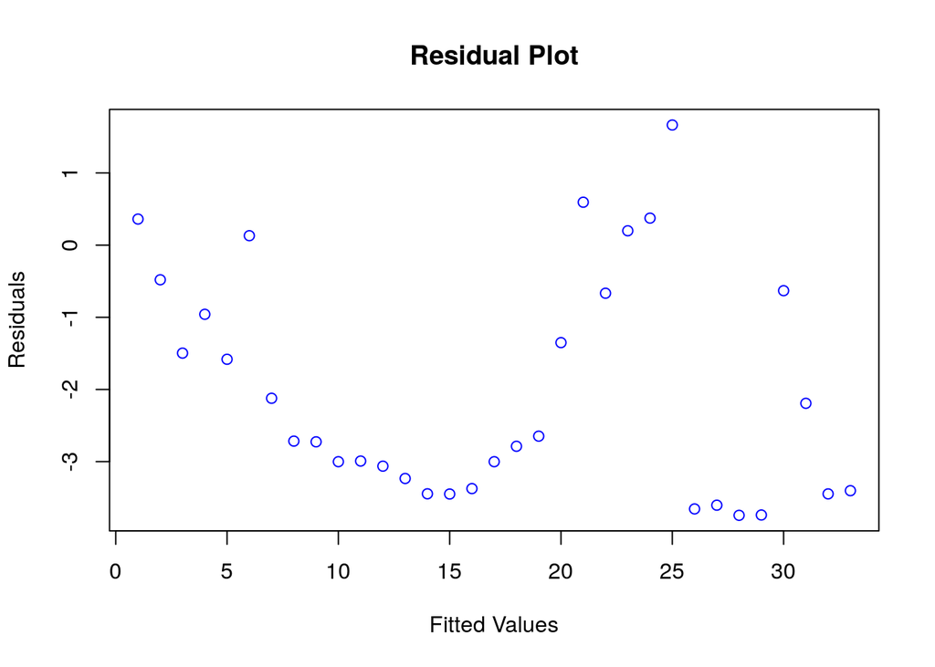

```r
year.size.art$resid %>%
   exp() -> year.size.art$exp.resid

plot(year.size.art$exp.resid - fitted(year.size.lm), ylab="Residuals",xlab="Fitted Values", main="Residual Plot", col="blue")
```

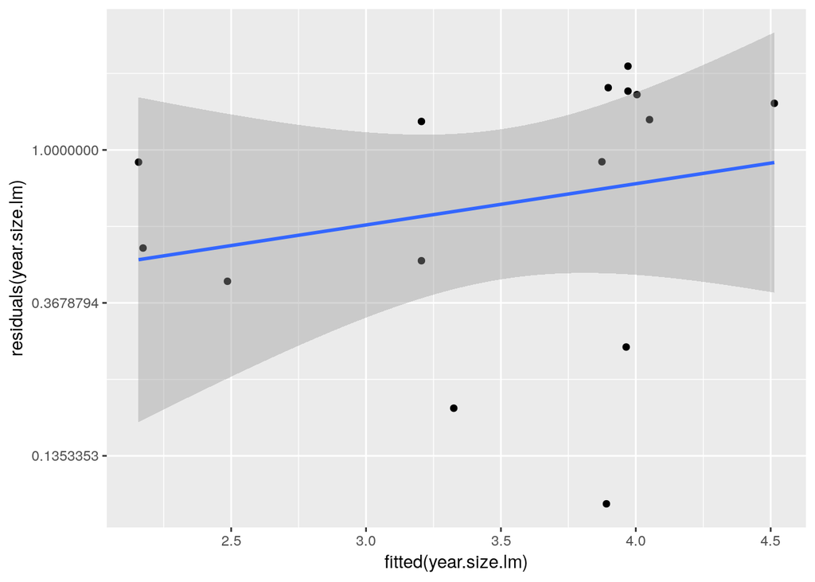

```r
ggplot(data=year.size.lm, aes(y=residuals(year.size.lm), x=fitted(year.size.lm))) +
 geom_point()+
 scale_y_continuous(trans="log") +
  stat_smooth(method=lm, formula=y~x)
```

# 4. Intervals and simulation

## Fit the deet and bites model from lab.

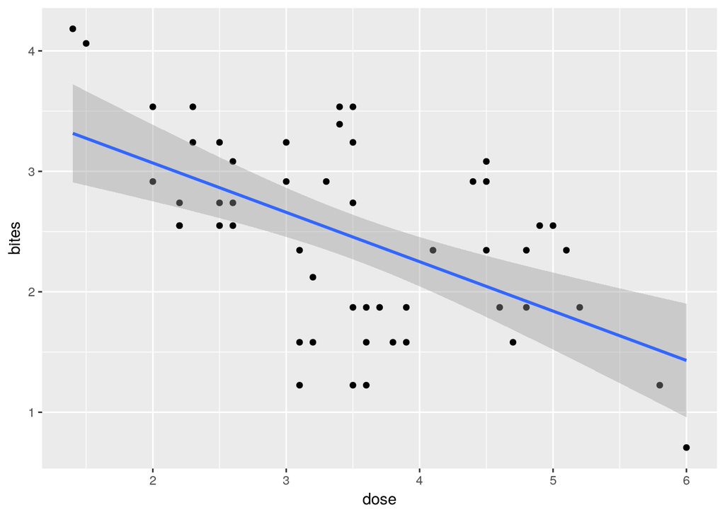

```r
deet <- read.csv("../data/17q24DEETMosquiteBites.csv")
ggplot(deet, aes(dose, bites)) +
  geom_point() +
  stat_smooth(method=lm)
```

> Now, look at `vcov()` applied to your fit. For example:

```r
deet.lm <- lm(bites ~ dose, data = deet)
deet.lm
```

```
##
## Call:
## lm(formula = bites ~ dose, data = deet)
##
## Coefficients:
## (Intercept)         dose
##      3.8890      -0.4098
```

```r
vcov(deet.lm)
```

```
##             (Intercept)         dose
## (Intercept)  0.09929780 -0.025986850
## dose        -0.02598685  0.007437073
```

## What you have here is the variance-covariance matrix of the parameters of the model. In essence, every time you larger slopes in this case will have smaller intercepts, and vice-verse. This maintains the best fit possible, despite deviations in the slope and intercept. BUT - what’s cool about this is that it also allows us to produce simulations (posterior simulations for anyone interested) of the fit. We can use a package like `mnormt` that let’s us draw from a multivariate normal distribution when provided with a vcov matrix. For example…

```r
library(mnormt)
rmnorm(4, mean = coef(deet.lm), varcov = vcov(deet.lm))
```

```
##      (Intercept)       dose
## [1,]    4.406152 -0.5463624
## [2,]    4.078978 -0.4593143
## [3,]    3.684373 -0.3630169
## [4,]    3.619590 -0.3069827
```

### 4a. Fit simulations!

> Using `geom_abline()` make a plot that has the following layers and shows that these simulated lines match up well with the fit CI. 1) the data, 2) the lm fit with a CI, and 3) simulated lines. You might have to much around to make it look as good as possible.

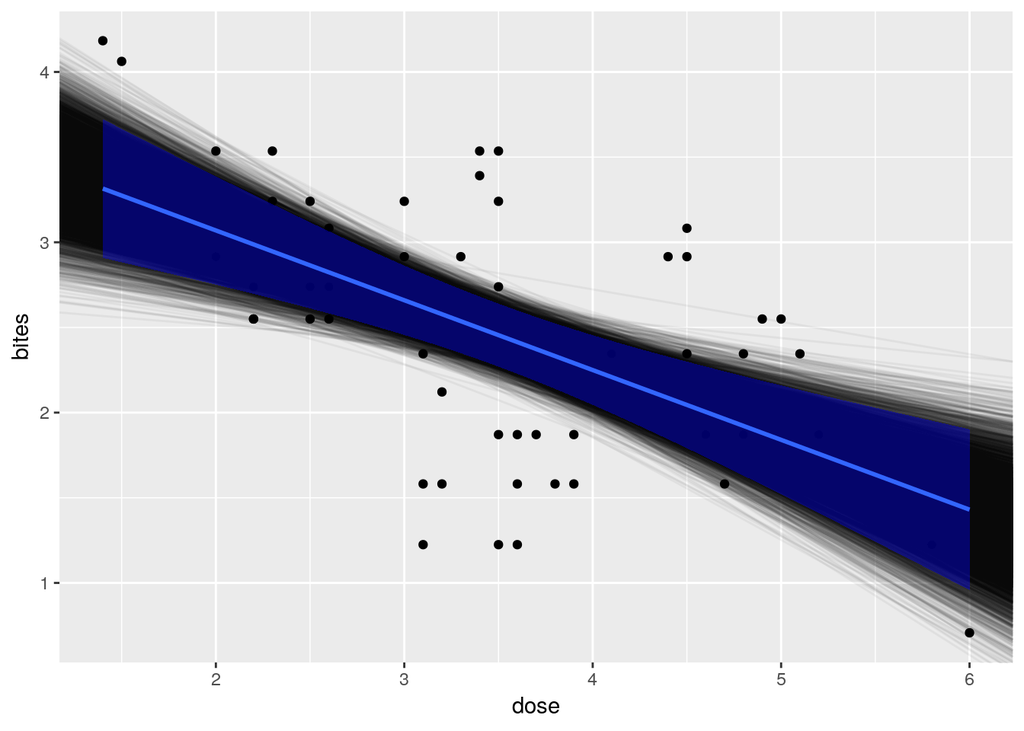

```r
coef.sim.df<-as.data.frame(rmnorm(10000, mean = coef(deet.lm), varcov = vcov(deet.lm)))

ggplot(deet, aes(dose, bites))+
  geom_point()+
  geom_abline(data = coef.sim.df, aes(slope = coef.sim.df$dose, intercept = coef.sim.df[,"(Intercept)"]),alpha=.05 )+
  stat_smooth(data = deet, method=lm, fill = "blue")
```

```r
confint(deet.lm)
```

```
##                  2.5 %     97.5 %
## (Intercept)  3.2560933  4.5219496
## dose        -0.5830094 -0.2365793
```

### 4b. Prediction simulations!

> That’s all well and good, but what about the prediction intervals? To each line, we can add some error drawn from the residual standard deviation. That residual can either be extracted from `summary()` or you can get the `sd` of `residuals`. Now, visualize the simulated prediction interval around the fit versus the calculated prediction interval around the fit via `predict`. **+1 extra credit for a clever visualization of all elements on one figure - however you would like**

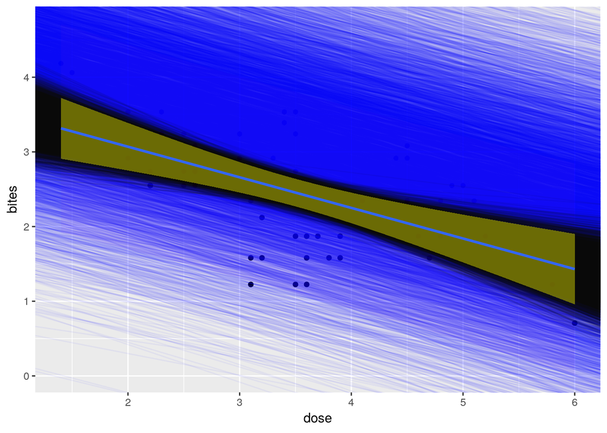

```r
coef.sim.df %>%
   mutate(std.err = rnorm(10000, sd(deet.lm$residuals))) -> coef.sim.df

pred.df <- predict(deet.lm, interval="prediction")
prediction.df<-cbind(pred.df, deet)

ggplot(deet, aes(dose, bites)) +
  geom_point() +
  geom_abline(data = coef.sim.df, aes(slope = coef.sim.df$dose, intercept = std.err+coef.sim.df[,"(Intercept)"]), alpha = 0.05, color = "Blue") +
  geom_ribbon(data = prediction.df, aes(ymin = prediction.df$lwr, ymax = prediction.df$upr), fill = "purple", alpha = 0.05) +
  geom_abline(data = coef.sim.df, aes(slope = coef.sim.df$dose, intercept = coef.sim.df[,"(Intercept)"]), alpha = 0.05) +
  stat_smooth(data = deet, method=lm, fill = "yellow")
```